# Ошибки I и II рода

## Требования к сдаче и оформлению задания

Заполните этот qmd-файл кодом и ответами. Порядок сдачи задания описан в README.md, на Stepik или Google-class.

1. Старайтесь соблюдать единый стиль оформления и структуру отчёта. Не оставляйте лишние чанки кода, текст или комментарии, которые не относятся к решению задания.
2. Основные результаты представьте на графиках и объясните в тексте. Отдельные таблицы результатов не требуются. Не оставляйте необработанный консольный вывод или отдельные числа без пояснений.
3. Графики должны быть достаточно крупными, с читаемыми русскими подписями, содержательным заголовком и правильно названными осями. Не используйте фон ggplot2 по умолчанию.
4. Ответы на вопросы и интерпретации результатов, включая графики, пишите обычным текстом, а не комментариями к коду. Код и его вывод не заменяют ответ на вопрос.
5. Сохраняйте исходную структуру проекта в репозитории. Не добавляйте лишние файлы, которые не относятся к проекту или выполнению заданий.
6. Оформление коммитов и веток на GitHub должно соответствовать общим правилам для всех курсов Института биоинформатики.

## О задании

На занятии мы оценивали ошибки I и II рода. Теперь с помощью симуляций вы **графически исследуете**, как вероятности этих ошибок у двухвыборочного t-теста зависят от уровня значимости, объёма выборки и распределения данных.

Для этого вы проведёте серии симуляций для разных **сочетаний параметров**.

**Результат выполнения домашнего задания: шесть графиков зависимости ошибки I или II рода от $\alpha$ и их интерпретация, выводы.**

## Условия

> Если условия не будут понятны с первого раза, то посмотрите на таблицу в разделе **“Сочетания условий”**.
1. Для сравнения средних двух независимых групп используйте `t.test()`.
2. Объём выборки в каждой из двух групп ($X$ и $Y$) должен быть одинаковым: **$n$ = 3, 10, 30, 100**. Здесь $n$ – объём **одной** выборки. В одном повторении сравниваются две выборки, то есть всего $2n$ наблюдений.
3. Исследуйте **нормальное, равномерное и экспоненциальное распределения**.
4. Проверяйте гипотезы $H_0: \mu_X = \mu_Y$ и $H_a: \mu_X \ne \mu_Y$. Для каждого типа распределения и объёма выборки рассмотрите два сценария:
- **$H_0$ верна:** генерируйте две независимые выборки из распределения с одинаковыми параметрами для обеих групп. Средние генеральных совокупностей равны.
- **$H_0$ неверна:** генерируйте две независимые выборки из распределений выбранного типа, выбрав параметры так, чтобы средние генеральных совокупностей различались.

> **Параметры распределений выберите один раз для каждого типа распределения и сценария.** В отчёте укажите выбранные параметры, истинные средние и истинные стандартные отклонения обеих групп. Затем сохраняйте параметры при изменении $n$ и $\alpha$.

> Рекомендуем для разных типов распределений задать одинаковое истинное среднее группы $X$ и одинаковое истинное среднее группы $Y$ в соответствующем сценарии.
5. Используйте уровни значимости **$\alpha = 0.01, 0.02, \ldots, 0.20$ с шагом 0.01**.
6. Для каждого сочетания типа распределения, объёма выборки и сценария проведите одну серию из **1000 повторений**. Вероятность ошибки оценивайте по её частоте в серии.

### Сочетания условий

**Переберите все сочетания:** 2 сценария × 3 типа распределений × 4 объёма выборки × 20 уровней значимости. В ячейках указан диапазон $\alpha$.

| Сценарий | Тип распределения | $n = 3$ | $n = 10$ | $n = 30$ | $n = 100$ |
| --- | --- | --- | --- | --- | --- |
| **$H_0$ верна** | Нормальное | $[0.01, 0.20]$ | $[0.01, 0.20]$ | $[0.01, 0.20]$ | $[0.01, 0.20]$ |
|  | Равномерное | $[0.01, 0.20]$ | $[0.01, 0.20]$ | $[0.01, 0.20]$ | $[0.01, 0.20]$ |
|  | Экспоненциальное | $[0.01, 0.20]$ | $[0.01, 0.20]$ | $[0.01, 0.20]$ | $[0.01, 0.20]$ |
| **$H_0$ неверна** | Нормальное | $[0.01, 0.20]$ | $[0.01, 0.20]$ | $[0.01, 0.20]$ | $[0.01, 0.20]$ |
|  | Равномерное | $[0.01, 0.20]$ | $[0.01, 0.20]$ | $[0.01, 0.20]$ | $[0.01, 0.20]$ |
|  | Экспоненциальное | $[0.01, 0.20]$ | $[0.01, 0.20]$ | $[0.01, 0.20]$ | $[0.01, 0.20]$ |

Каждая ячейка с диапазоном $\alpha$ соответствует одной серии из **1000 повторений** для указанного сценария, типа распределения и объёма выборки. **Один и тот же набор p-значений этой серии используйте для всех 20 уровней $\alpha$: новые выборки для каждого $\alpha$ генерировать не нужно.**

Всего получится **24 серии**. Для каждой серии оцените вероятность ошибки I или II рода (в зависимости от сценария) при всех **20 уровнях $\alpha$**. В результате получите по **240 оценок для каждого типа ошибки (сценария)**.

## Проведение симуляции

1. **Задайте seed один раз перед симуляциями**.
2. В каждом повторении генерируйте две новые независимые выборки, применяйте t-тест и сохраняйте p-значение.
3. Проведите симуляции и сохраните оценки вероятностей ошибок I или II рода для каждого сочетания типа распределения, объёма выборки, сценария и уровня значимости.

```r
set.seed(30)
```

## Постройте графики

1. Постройте шесть графиков: **три распределения × два типа ошибок**. Допустимы шесть отдельных рисунков или один общий рисунок из шести панелей.
2. На каждом графике по оси **X** отложите $\alpha$, по оси **Y** – вероятность ошибки I или II рода. Покажите **четыре кривые**, соответствующие объёмам выборки $n = 3, 10, 30, 100$.
3. Используйте одинаковые цвета для одинаковых $n$ и одинаковые границы осей для одного типа ошибки.

> На графиках для ошибки I рода добавьте пунктирную линию **$y = \alpha$** для сравнения с заданным уровнем значимости.

## Выводы

Напишите выводы, попутно ответив на вопросы:

1. Насколько оценённая вероятность ошибки I рода близка к $\alpha$ в каждом случае? Видны ли отклонения для каких-либо распределений и объёмов выборки? Если видны, в какую сторону?
2. Как меняется вероятность ошибки II рода при изменении $\alpha$ и $n$? Как вы думаете, почему?
3. Чем различаются результаты для трёх распределений?
4. Почему оценённая частота ошибки I рода может не совпадать с $\alpha$?

## Дополнительное задание

Выберите один тип распределения и объём выборки $n=10$. Для каждого из двух сценариев возьмите параметры из основного задания и рассмотрите ещё два варианта, изменяя один выбранный параметр распределения. Укажите, какой параметр и в какой группе или группах вы изменяете.

Остальные параметры распределения, объём выборки, уровни $\alpha$ и число повторений оставьте прежними.

**Постройте два графика**: для ошибки I рода и для ошибки II рода. На каждом покажите три кривые – исходный вариант (из основного задания) и два изменённых.

# Какие изменения вы наблюдаете? Почему?

Решение задачи Выбранные параметры распределений 1.Нормальное распределение: Группа X: среднее значение = 0, стандартное отклонение = 1. Группа Y (нулевая гипотеза верна): среднее значение = 0, стандартное отклонение = 1. Группа Y (нулевая гипотеза неверна): среднее значение = 1, стандартное отклонение = 1.

2.Равномерное распределение: Группа X: границы от 0 до 2. Среднее значение = 1, стандартное отклонение ≈ 0.577. Группа Y (нулевая гипотеза верна): границы от 0 до 2. Среднее значение = 1, стандартное отклонение ≈ 0.577. Группа Y (нулевая гипотеза неверна): границы от 1 до 3. Среднее значение = 2, стандартное отклонение ≈ 0.577.

3.Экспоненциальное распределение: Группа X: параметр rate = 1. Среднее значение = 1, стандартное отклонение = 1. Группа Y (нулевая гипотеза верна): параметр rate = 1. Среднее значение = 1, стандартное отклонение = 1. Группа Y (нулевая гипотеза неверна): параметр rate = 0.5. Среднее значение = 2, стандартное отклонение = 2.

```r
library(tidyverse)
```

```r
n_values <- c(3, 10, 30, 100)
dist_values <- c("Нормальное", "Равномерное", "Экспоненциальное")
scenario_values <- c("H0 верна", "H0 неверна")
alpha_values <- seq(from = 0.01, to = 0.20, by = 0.01)
stringsAsFactors = FALSE
results <- data.frame(
  n          = numeric(),
  dist       = character(),
  scenario   = character(),
  alpha      = numeric(),
  error_rate = numeric(),
  stringsAsFactors = FALSE
)
```

```r
for (n in n_values) {
  for (dist in dist_values) {
    for (scenario in scenario_values) {
      p_values <- numeric(1000)

      for (i in 1:1000) {

        if (dist == "Нормальное") {
          x <- rnorm(n, mean = 0, sd = 1)
        } else if (dist == "Равномерное") {
          x <- runif(n, min = 0, max = 2)
        } else {
          x <- rexp(n, rate = 1)
        }

        if (dist == "Нормальное") {
          if (scenario == "H0 верна") {
            y <- rnorm(n, mean = 0, sd = 1)
          } else {
            y <- rnorm(n, mean = 1, sd = 1)
          }
        } else if (dist == "Равномерное") {
          if (scenario == "H0 верна") {
            y <- runif(n, min = 0, max = 2)
          } else {
            y <- runif(n, min = 1, max = 3)
          }
        } else {
          if (scenario == "H0 верна") {
            y <- rexp(n, rate = 1)
          } else {
            y <- rexp(n, rate = 0.5)
          }
        }
        #Применяем двухвыборочный t-тест Уэлча (в R по умолчанию используется именно он, так как он не требует равенства дисперсий) к выборкам x и y.
        test_result <- t.test(x, y)
        p_values[i] <- test_result$p.value
        }
        for (alpha in alpha_values) {

        if (scenario == "H0 верна") {
          errors <- sum(p_values < alpha)
        } else {
          errors <- sum(p_values >= alpha)
        }

        error_rate <- errors / 1000

        new_row <- data.frame(
          n          = n,
          dist       = dist,
          scenario   = scenario,
          alpha      = alpha,
          error_rate = error_rate,
          stringsAsFactors = FALSE
        )

        results <- rbind(results, new_row)
      }

    }
  }
}
```

```r
print(dim(results))
```

```
[1] 480   5
```

```r
print(head(results))
```

```
  n       dist scenario alpha error_rate
1 3 Нормальное H0 верна  0.01      0.005
2 3 Нормальное H0 верна  0.02      0.011
3 3 Нормальное H0 верна  0.03      0.012
4 3 Нормальное H0 верна  0.04      0.024
5 3 Нормальное H0 верна  0.05      0.030
6 3 Нормальное H0 верна  0.06      0.038
```

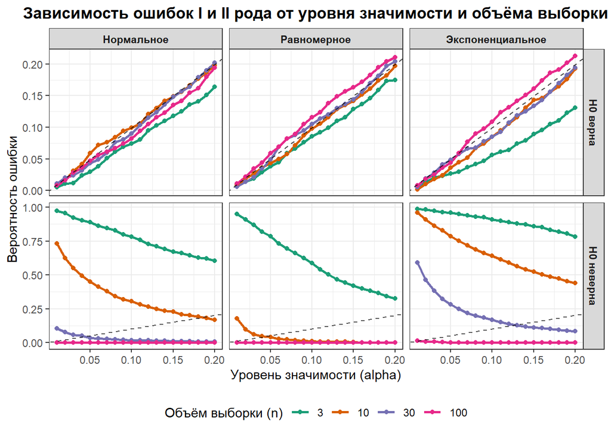

```r
# Строим график
ggplot(results, aes(x = alpha, y = error_rate, color = factor(n), group = factor(n))) +
  geom_line(size = 1) +
  geom_point(size = 1.5) +
  geom_abline(intercept = 0, slope = 1, linetype = "dashed", color = "black", alpha = 0.7) +
  # Разделяем на 6 панелей
  facet_grid(scenario ~ dist, scales = "free_y") +
  labs(
    x = "Уровень значимости (alpha)",
    y = "Вероятность ошибки",
    color = "Объём выборки (n)",
    title = "Зависимость ошибок I и II рода от уровня значимости и объёма выборки"
  ) +
  scale_color_brewer(palette = "Dark2") +
  theme_bw() +
  theme(
    legend.position = "bottom",
    plot.title = element_text(hjust = 0.5, face = "bold"),
    strip.text = element_text(face = "bold")
  )
```